# Tables-Figures-vignette

# 1 Tables

There are three packages I recommend for generating tables: `kableExtra`, `arsenal`, and `sjPlot`.

- `kable` from the `kableExtra` package for printing tables from data frames.
- `tableby` from the `arsenal` package for creating summary tables.
- `tab_model` from the `sjPlot` package for creating HTML tables with model results.

We are currently aware of two packages that should be avoided for table generation when using the template: `table1` and `DT`. The tables that result from these packages do not work with the auto-numbering and cross-referencing functionality of [bookdown](https://bookdown.org/yihui/rmarkdown-cookbook/cross-ref.html).

## 1.1 kableExtra

Use `kable(data.frame)` or pipe a data frame into `kable` to create a table using `kableExtra`. To cross-reference a `kableExrta` table, reference the chunk name (`\@ref(tab:chunk-name)`). An example is shown in Table 1.1. For more information on using and modifying tables with kableExtra see their [vignette](https://cran.r-project.org/web/packages/kableExtra/vignettes/awesome_table_in_html.html).

```r
iris %>%
  group_by(Species) %>%
  summarise("Mean (SD)" = paste0(round(mean(Sepal.Length), 3), " (",
                                 round(sd(Sepal.Length), 3), ")"),
            "Range" = paste0(round(min(Sepal.Length), 3), " - ",
                             round(max(Sepal.Length), 3))) %>%
  t() %>%
  kable(caption = "Summary of sepal length by species.") %>%
  kable_styling()
```

Table 1.1: Table 1.2: Summary of sepal length by species.

| Species | setosa | versicolor | virginica |
| --- | --- | --- | --- |
| Mean (SD) | 5.006 (0.352) | 5.936 (0.516) | 6.588 (0.636) |
| Range | 4.3 - 5.8 | 4.9 - 7 | 4.9 - 7.9 |

## 1.2 arsenal

Create a summary table using `arsenal::tableby`. Make sure to set the chunk option `results='asis'` for the results to look nice within the report. To cross-reference a `tableby` object, reference the chunk name (`\@ref(tab:chunk-name)`). An example is show in Table 1.3. For more information on using `tableby` see their [vignette](https://cran.r-project.org/web/packages/arsenal/vignettes/tableby.html).

```r
summary(arsenal::tableby(Species ~ Sepal.Length, data = iris),
        title = "Summary of sepal lengths by species.")
```

Table 1.3: Summary of sepal lengths by species.

|  | setosa (N=50) | versicolor (N=50) | virginica (N=50) | Total (N=150) | p value |
| --- | --- | --- | --- | --- | --- |
| **Sepal.Length** |  |  |  |  | < 0.001 |
| Mean (SD) | 5.006 (0.352) | 5.936 (0.516) | 6.588 (0.636) | 5.843 (0.828) |  |
| Range | 4.300 - 5.800 | 4.900 - 7.000 | 4.900 - 7.900 | 4.300 - 7.900 |  |

The `tableby` vignette says to add `(\\#tab:table-label)` at the beginning of the title in order to reference with `bookdown` but I’ve found this causes the table to be numbered twice, as seen in table 1.5.

```r
summary(arsenal::tableby(Species ~ Sepal.Length, data = iris),
        title = "(\\#tab:tableby-table) Summary of sepal lengths by species.")
```

Table 1.4: Table 1.5: Summary of sepal lengths by species.

|  | setosa (N=50) | versicolor (N=50) | virginica (N=50) | Total (N=150) | p value |
| --- | --- | --- | --- | --- | --- |
| **Sepal.Length** |  |  |  |  | < 0.001 |
| Mean (SD) | 5.006 (0.352) | 5.936 (0.516) | 6.588 (0.636) | 5.843 (0.828) |  |
| Range | 4.300 - 5.800 | 4.900 - 7.000 | 4.900 - 7.900 | 4.300 - 7.900 |  |

## 1.3 sjPlot

The `tab_model` function from the `sjPlot` package will create an HTML summary table of a model object. To cross-reference a `tab_model` table, add `(\\#tab:table-label)` at the beginning of the title. An example is shown in Table 1.6. For more information on using `tab_model` see their [vignette](https://strengejacke.github.io/sjPlot/articles/tab_model_estimates.html).

```r
sjPlot::tab_model(lm(Sepal.Length ~ Species, data = iris),
                  title = "(\\#tab:sjplot-table) Results of linear regression model.")
```

Table 1.6: Results of linear regression model.

|  | Sepal Length |  |  |
| --- | --- | --- | --- |
| Predictors | Estimates | CI | p |
| (Intercept) | 5.01 | 4.86 – 5.15 | **<0.001** |
| Species [versicolor] | 0.93 | 0.73 – 1.13 | **<0.001** |
| Species [virginica] | 1.58 | 1.38 – 1.79 | **<0.001** |
| Observations | 150 |  |  |
| R<sup>2</sup> / R<sup>2</sup> adjusted | 0.619 / 0.614 |  |  |

# 2 Figures

As of this writing I am not aware of any figure packages that should be avoided. Each figure should be in its own chunk with a figure caption when being printed. As with the `kableExtra` and `tableby` tables, reference the figures using the chunk name (`\@ref(fig:chunk-name)`). Figure 2.1 is an example.

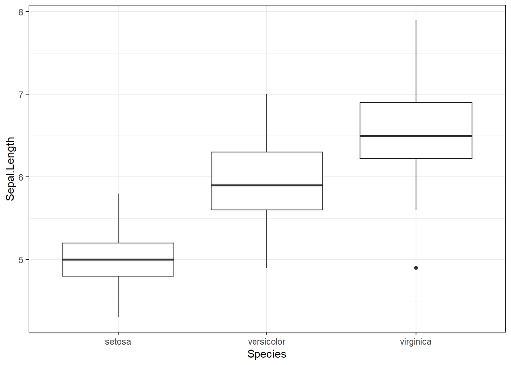

Figure 2.1: Boxplot of sepal length by species.

```r
ggplot(iris, aes(x = Species, y = Sepal.Length)) +
  geom_boxplot() +
  theme_bw()
```

As with the `tableby` table, including `(\\#fig:fig-label)` at the beginning of the figure caption will result in double numbering, as shown in Figure 2.3.

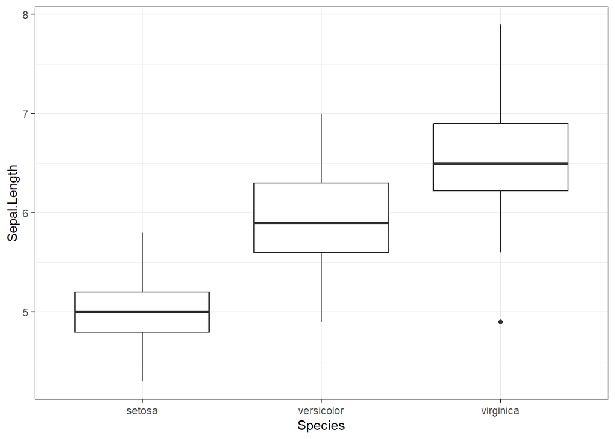

Figure 2.2: Figure 2.3: Boxplot of sepal length by species.

```r
ggplot(iris, aes(x = Species, y = Sepal.Length)) +
  geom_boxplot() +
  theme_bw()
```